# Navelski Homework 1

J. Navelski

9/16/2020

```r
summary(cars)
```

```
##      speed           dist
##  Min.   : 4.0   Min.   :  2.00
##  1st Qu.:12.0   1st Qu.: 26.00
##  Median :15.0   Median : 36.00
##  Mean   :15.4   Mean   : 42.98
##  3rd Qu.:19.0   3rd Qu.: 56.00
##  Max.   :25.0   Max.   :120.00
```

## Question 1

#### Deriving the $E(X)$ for a Binomial RV

Let,
$$X \sim Bin(x;n,p)$$
Then
$$E(X) = E\left(\binom{n}{x} \cdot p^x(1-p)^{n-x} \right)$$
$$= \sum_{x=0}^{n}x\binom{n}{x} \cdot p^x(1-p)^{n-x}$$
Where, we know that the term where $x=0$ vanishes, and the final term of the $x!$ in the denominator cancels s.t.
$$= \sum_{x=1}^{n}\frac{n!}{(x-1)!(n-x)!} \cdot p^x (1-p)^{n-x}$$
This implies that we can let $y=x-1$ and $m=n-1$, and thus substitute for $x-1$ and $n=m+1$ into the last sum (and using the fact that the limits of $x=1$ and $x=n$ correspond to $y=0$ and $y=n-1=m$, respectivly) we get
$$= \sum_{y=0}^{m}\frac{(m+1)!}{y!(m-y)!} \cdot p^{y+1}(1-p)^{m-y}$$
$$= \sum_{y=0}^{m}\frac{(m+1)!}{y!(m-y)!} \cdot p^{y+1}(1-p)^{m-y}$$
Where we can pull out the $(m+1)$ and $p$ s.t.
$$= (m+1)p\sum_{y=0}^{m}\frac{(m)!}{y!(m-y)!} \cdot p^{y}(1-p)^{m-y}$$
and the Binomial Therom says
$$(a+b)^{m}= \sum_{y=0}^{m}\frac{(m)!}{y!(m-y)!} \cdot a^{y}b^{m-y}$$
and thus implies that
$$\implies \hspace{.5cm} E(X) = (m+1)p(p+1-p)^{m}=np$$
since $n-1=m$ and $(p+1-p)^{m}=1$. \ \ \

#### Deriving the $V(X)$ for a Binomial RV

Simalarly to above, we can use a trick where we find $E(X(X-1))$ using the assumption that $y=x-2$ and $m=n-2$ s.t.
$$E(X(X-1))= \sum_{x=0}^{n}x(x-1)\binom{n}{x} \cdot p^x(1-p)^{n-x}$$
$$= \sum_{x=2}^{n}\frac{n!}{(x-2)!(n-x)!} \cdot p^x(1-p)^{n-x}$$
$$= n(n-1)p^{2} \sum_{x=2}^{n}\frac{(n-2)!}{(x-2)!(n-x)!} \cdot (1-p)^{x-2}q^{n-x}$$
$$= n(n-1)p^{2} \sum_{y=0}^{m}\frac{(m)!}{y!(m-y)!} \cdot p^{y}(1-p)^{m-y}$$
$$= n(n-1)p^{2} (p+1-p)^{m}$$
$$\implies \hspace{.5cm} E(X(X-1)) = n(n-1)p^{2}$$
That said, using the variance formula we can get the useful form of
$$V(X) = E[(X-E(X))(X-E(X))]$$
$$= E[X^{2}-2XE(X)+E(X)^{2}]$$
$$= E(X^{2})-E(X)^{2}$$
$$= E(X^{2})+E(X)-E(X)-E(X)^{2}$$
$$= E(X(X-1))+E(X)-E(X)^{2}$$
and inserting our known results
$$= n(n-1)p^{2}+np-n^{2}p^{2}$$
$$= n^{2}p^{2}-np^{2}+np-n^{2}p^{2}$$
$$\implies \hspace{.5cm}V(X) = np(1-p)$$

## Question 2

#### Deriving the MLE of an Exponential Distribution and a Normal Distribution

$2.1)$ MLE of Exponetial Dist.

Let a sample $x_{i}, \dots, x_{n}$ be drawn from a random variable $X\sim Exp(\lambda)$ with a probability drawn from a PDF of

$$\begin{equation}
f_{X}(x_{1},\dots,x_{i},\dots,x_{n})=
\begin{cases}
\lambda exp(-\lambda x_{i}), & \text{if}\ x_{i} \in [0,\infty)\\
0, & \text{otherwise}
\end{cases}
\end{equation}$$

To get the MLE of if this distribution we first use the joint probability distribution to get the likelihood function s.t.
$${L}(\lambda ; x_{1},\dots,x_{n}) = \prod_{i=1}^{n}f(x_{i};\lambda)$$
$$= \prod_{i=1}^{n}\left(\lambda exp(-\lambda x_{i})\right)$$
$$= \lambda^{n}exp\left(- \lambda \sum_{i=1}^{n}x_{i} \right)$$
and we log the liklihood of the function to make calculations easier s.t.
$$\mathcal{L} (\lambda ; x_{1},\dots,x_{n}) = log\left(\lambda^{n}exp\left(- \lambda \sum_{i=1}^{n}x_{i} \right) \right)$$
$$= log\left(\lambda^{n}\right) - \lambda \sum_{i=1}^{n}x_{i}$$
Taking the derivite of the log-likelihood function with respect to the distribution's parameter $(\lambda)$ will ensure that we choose the optimal parameter that maximizes the joint probability of observing those data points s.t.
$$\frac{\partial \mathcal{L} (\lambda ; x_{1},\dots,x_{n})}{\partial \lambda} = \frac{n}{\lambda}-\sum_{i=1}^{n}x_{i} \hspace{.5cm} = \hspace{.5cm} 0$$
$$\frac{n}{\lambda} = \sum_{i=1}^{n}x_{i}$$
$$\implies \lambda_{MLE} \equiv \hat{\lambda} = \frac{n}{\sum_{i=1}^{n}x_{i}}$$
which is just the recipocal of the sample mean such that
$$\hat{\lambda} = \frac{1}{\overline{x}}$$

$2.2)$ MLE of Normal Dist. with know variance ($\sigma$)

Let a sample $x_{i}, \dots, x_{n}$ be drawn from a random variable $X\sim \mathcal{N} (\mu,\sigma^{2})$, where $\sigma_{2}$ is know, with a probability drawn from a PDF of

$$\begin{equation}
f_{X}(x_{1},\dots,x_{i},\dots,x_{n})=
\begin{cases}
\frac{1}{\sigma \sqrt{2\pi}} exp\left(-\frac{1}{2}\left( \frac{x_{i}-\mu}{\sigma} \right)^{2}\right), & \text{if}\ x_{i} \in (-\infty,\infty) \text{ and } \ \sigma^{2} \in [0,\infty) \\
0, & \text{otherwise}
\end{cases}
\end{equation}$$

To get the MLE of if this distribution we first use the joint probability distribution to get the likelihood function s.t.
$${L}(\mu , \sigma^{2} ; x_{1},\dots,x_{n}) = \prod_{i=1}^{n}f(x_{i};\mu,\sigma^{2})$$
$$= \prod_{i=1}^{n}\left( \frac{1}{\sigma\sqrt{2\pi}} exp\left(-\frac{1}{2}\left( \frac{x_{i}-\mu}{\sigma} \right)^{2}\right)\right)$$
$$= \left( \frac{n}{\sigma\sqrt{2\pi}} exp\left(-\frac{1}{2\sigma^{2}}\sum_{i=1}^{n}\left(x_{i}-\mu \right)^{2}\right)\right)$$
$$= \frac{n}{\sigma\sqrt{2\pi}} exp\left(-\frac{1}{2\sigma^{2}}\sum_{i=1}^{n}\left(x_{i}-\mu \right)^{2}\right)$$
and we log the liklihood of the function to make calculations easier s.t.
$$\mathcal{L} (\mu, \sigma^{2} ; x_{1},\dots,x_{n}) = log\left( \frac{n}{\sigma\sqrt{2\pi}} exp\left(-\frac{1}{2\sigma^{2}}\sum_{i=1}^{n}\left(x_{i}-\mu \right)^{2}\right) \right)$$
$$= -\frac{n}{2}log\left(\sqrt{2\pi}\right) -\frac{n}{2}log(\sigma^{2}) -\frac{1}{2\sigma^{2}} \sum_{i=1}^{n} \left( x_{i}-\mu \right)^{2}$$
Taking the derivite of the log-likelihood function with respect to the distribution's parameter $(\mu)$ will ensure that we choose the optimal parameter that maximizes the joint probability of observing those data points s.t.
$$\frac{\partial \mathcal{L} (\lambda ; x_{1},\dots,x_{n})}{\partial \mu} = -2\frac{1}{2\sigma^{2}} \sum_{i=1}^{n} \left( x_{i}-\mu \right) (-1) = \hspace{.5cm} 0$$
$$\frac{1}{2\sigma^{2}} \sum_{i=1}^{n} \left( x_{i}-\mu \right) = \hspace{.5cm} 0$$
$$\sum_{i=1}^{n} \left( x_{i}\right) = \sum_{i=1}^{n} \left( \mu \right)$$
$$\implies \mu_{MLE} \equiv \hat{\mu} = \frac{\sum_{i=1}^{n} x_{i}}{n}$$

## Question 3

## Question 4

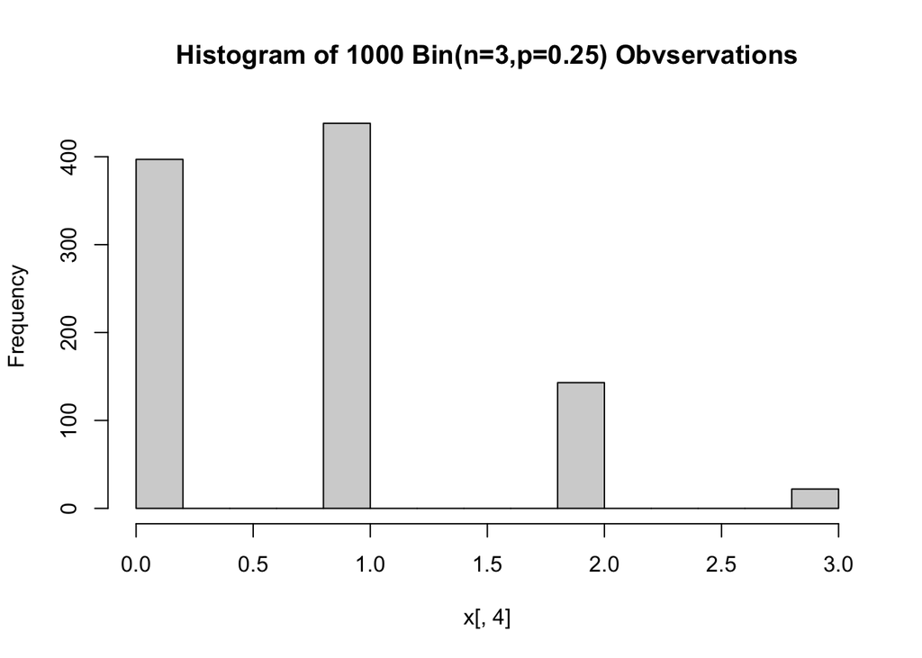

```r
x = matrix(0,nrow = 1000, ncol = 4)
p=.25
for(i in 1:1000){
  for(j in 1:3){
    x[i,j] = runif(n=1,0,1)
    x[i,j] = ifelse(x[i,j]<(1-p),0,1)
  }
}

for(i in 1:1000){
      x[i,4]=sum(x[i,1:3])
}

hist(x[,4], main = "Histogram of 1000 Bin(n=3,p=0.25) Obvservations")
```

## Question 5

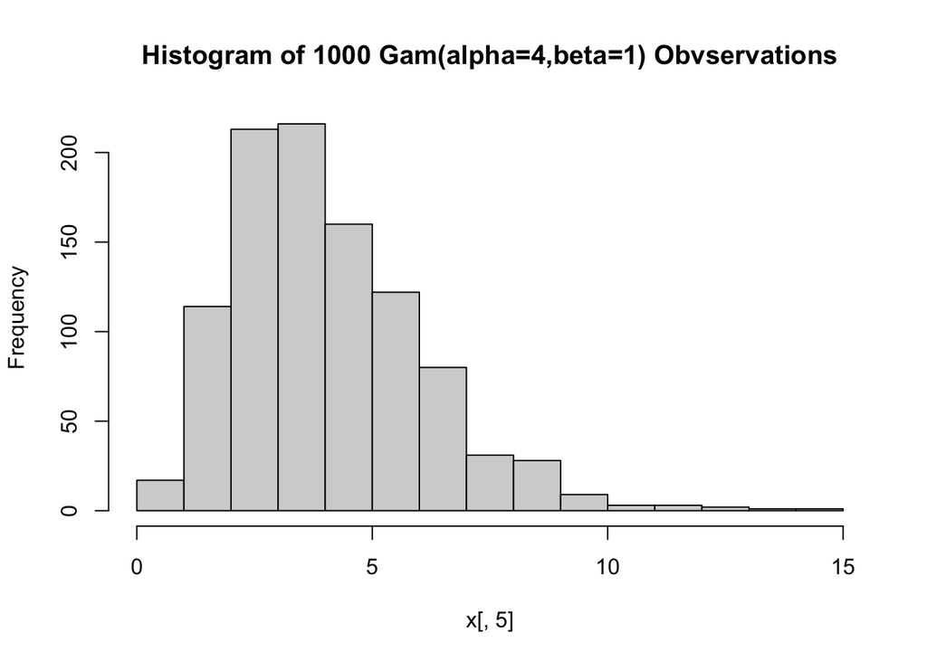

```r
alpha = 4
beta = 1

x = matrix(0,nrow = 1000, ncol = alpha+1)

for(i in 1:1000){
  for(j in 1:4){
      x[i,j] = runif(1,0,1)
  }
}

for(i in 1:1000){
      x[i,5]=-beta*(sum(log(x[i,1:alpha])))
}

hist(x[,5], main = "Histogram of 1000 Gam(alpha=4,beta=1) Obvservations")
```

## Question 6

## Question 7

#### Part B

Consider that the instrumental variable $Y$ to be distributed $Y \sim \mathcal{U}[0,1]$ and generate a sample size of $n$ from $X$, where $X$ is distributed $X \sim Beta(c+1,c+1)$, using the Accept-Reject (AR) method.

Let,
$$h(X) \equiv \frac{f(X)}{g(X)} = \frac{1}{B(c+1,c+1)}X^{(c+1)-1}(1-X)^{(c+1)-1}$$
$$= \frac{(X(X-1))^{c}}{B(c+1,c+1)}$$
since $g(X) = 1$ and simplifying. We can take the log and find the optimal $M$ implicitly through finding the supremum of $h(X)$ s.t.
$$log(h(X)) = log \left(\frac{(X(X-1))^{c}}{B(c+1,c+1)}\right)$$
$$log(h(X)) = c*log(X)+c*log(1-X)-log\left( B(c+1,c+1) \right)$$
Taking the first order conditions
$$\frac{\partial log(h(X))}{\partial X} = \frac{c}{X}-\frac{c}{1-X} \hspace{.5cm}=\hspace{.5cm}0$$
$$\implies X^{*} = \frac{1}{2}$$
we get the optimal value of $X$ that allows us to choose the optimal value of $M$ s.t.
$$M^{*}(X^{*})=h(X^{*}=\frac{1}{2})=\frac{\left(\frac{1}{2}\left(\frac{1}{2}-1\right)\right)^{c}}{B(c+1,c+1)}$$
$$= \frac{\left(\frac{1}{4}\right)^{c}}{B(c+1,c+1)}$$
$$\implies \hspace{.5cm} M^{*}(X^{*}) = \left(\frac{1}{4}\right)^{c} \frac{1}{B(c+1,c+1)}$$
Using this condition on $M^* ( X^* )$ we can the formulate the AR algorythim as: Accept realization if
$$u_{1} \leq \frac{\left( \frac{(X(X-1))^{c}}{B(c+1,c+1)} \right) }{\left( \left(\frac{1}{4}\right)^{c} \frac{1}{B(c+1,c+1)} \right) } \hspace{.5cm} \equiv \hspace{.5cm} \frac{f(X)}{M^{*}g(X)}$$
$$u_{2} \leq 4^{c}(X(1-X))^{c} \hspace{.5cm} \text{where }X\sim\mathcal{U}(0,1) \text{ and } c \text{ is a constant}$$
and reject and redraw otherwise.